# Outside Item Memory

> This notebook focuses on item memory outside the rooms for the intermediate version.

# 1 Overview of the data

The rooms were separated into *Familiar* and *Novel* groups. Participants explored the *Familiar* group at the beginning of the experiment. In the encoding task, they visisted both *Familiar* and *Novel* groups. Their item memory (i.e., in which room they saw the item) was tested in the memory test the next day of the encoding task. **Novelty benefits** on the item memory are examined by comparing the memory performance between the *Familiar* and *Novel* groups.

Participants were also asked to rate how curious they felt about the room. The higher the rating is means they felt more curious about the room. Item memory as a function of curiosity rating was also examined for **curiosity benefits**.

In the encoding task, there were 6 objects in each room, and the participant saw the object after openning each of the six box. It is possbile that the item memory for the object to some extent depends on the order in which the object was seen. For example, it may be easier to remember where the first and last objects were seen as compared to those in the middle.

# 2 Visual inspection of the data

[figure not shown]

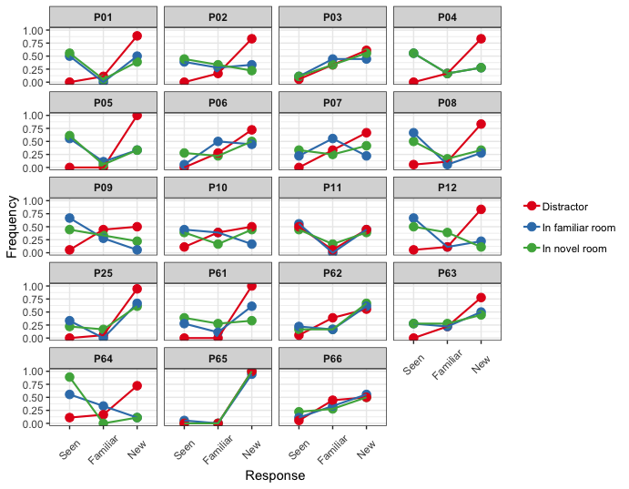

# 3 Novelty Benefits

We hypothesised that the memory for the items outside the rooms should be better for the *novel* rooms than for the *familiar* rooms.

## 3.1 Compare mean accuracy between *novel* and *familiar* rooms

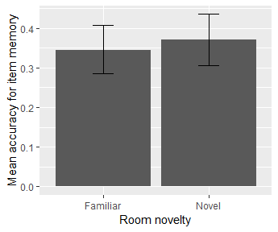

```
    Paired t-test

data:  MeanSeenHit by Group
t = -0.8991, df = 39, p-value = 0.3741
alternative hypothesis: true difference in means is not equal to 0
95 percent confidence interval:
 -0.06770168  0.02603501
sample estimates:
mean of the differences
            -0.02083333
```

## 3.2 Item memory as a function of item order

### 3.2.1 Visualise the data

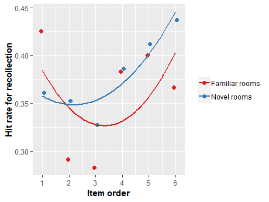

### 3.2.2 Testing novelty effects by fitting mixed models

Build models with recollection hit rate as $y$ and examine effects of item order and novelty by including the predictors one by one and then comparing the models.

- `baseline.item` is the model with only an intercept.
- `order.model.linear.1` is the model with $\small ItemOrder$ included, showing the effects of item order.
- `order.model.linear.2` is the model allowing the slope (i.e., relationship between item memory and item order) varying across participants.
- `order.model.quad.1` and `order.model.quad.2` repectively included $\small ItemOrder^2$ and related random effects.
- `novelty.model.1` is the model with $\small Group$ (i.e., *familiar* and *novel* rooms) included, examining the effects of novelty of the rooms on the intercept (i.e., mean item memory accuracy at the 1st order or overall if no difference in slope).
- `novelty.model.2` is the model with interaction between $\small Group$ and $\small ItemOrder$ included, examining the effects of novelty on how item memory accuracy changes as a function of item order.
- `novelty.model.3` included interaction between $\small Group$ and $\small ItemOrder^2$ for inestigating whether the pattern changes between *familiar* and *novel* groups.

|  | Model | df | AIC | BIC | logLik | Test | L.Ratio | p-value |
| --- | --- | --- | --- | --- | --- | --- | --- | --- |
| baseline.item | 1 | 4 | 1909.611 | 1930.684 | -950.8053 |  |  |  |
| order.model.linear.1 | 2 | 5 | 1909.368 | 1935.709 | -949.6839 | 1 vs 2 | 2.242952 | 0.1342 |
| order.model.linear.2 | 3 | 9 | 1917.362 | 1964.776 | -949.6812 | 2 vs 3 | 0.005300 | 1.0000 |
| order.model.quad.1 | 4 | 10 | 1916.181 | 1968.863 | -948.0905 | 3 vs 4 | 3.181342 | 0.0745 |
| novelty.model.1 | 5 | 11 | 1917.459 | 1975.410 | -947.7297 | 4 vs 5 | 0.721596 | 0.3956 |
| novelty.model.2 | 6 | 12 | 1918.524 | 1981.742 | -947.2618 | 5 vs 6 | 0.935767 | 0.3334 |
| novelty.model.3 | 7 | 13 | 1920.344 | 1988.831 | -947.1721 | 6 vs 7 | 0.179418 | 0.6719 |

#### 3.2.2.1 Parameter estimation for the complete model

# 4 Curiosity Benefits

We hypothesed that the higher the curiosity rating was, the better the item memory should be.

## 4.1 Mean accuracy of item memory as a function of curiosity rating

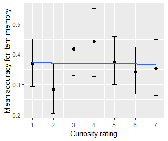

### 4.1.1 Testing the relationship between mean accuracy of item memory and curiosity rating

Build models with item memory accuracy as $y$ and examine effects of curiosity rating by including it into the model and then comparing the model fits.

- `baseline.rating` is the model with only an intercept, showing no change in item memory as a function of curiosity rating.
- `rating.intercept` is the model with $\small CuriosityRating$ included, showing the effects of curiosity rating.
- `rating.slope` is the model allowing the slope (i.e., relationship between item memory and curiosity rating) varying across participants.

## 4.2 Does the relationship with curiosity rating depend on item order?

### 4.2.1 Testing the effect of item order

Build models with context memory accuracy as $y$ and examine effects of curiosity rating and item order by comparing the models.

- `item.model.linear.1` is the model with $\small ItemOrder$ included (in addition to $\small CuriosityRating$), showing the effects of item order.
- `item.model.linear.2` is the model allowing the slope (i.e., relationship between item memory and item order) varying across participants.
- `item.model.linear.3` is the model with the interaction between $\small ItemOrders$ and $\small CuriosityRating$ included.
- `item.model.quad.1` and `item.model.quad.2` repectively included $\small ItemOrder^2$ and related random effects.
- `item.model.quad.3` included interaction between $\small ItemOrder^2$ and $\small CuriosityRating$ for inestigating whether the pattern changes as a function of *curiosity rating*.

### 4.2.2 Collapse the order and curiosity rating

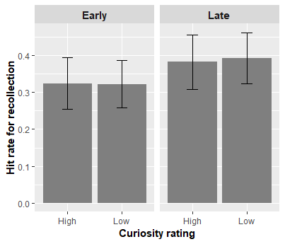

#### 4.2.2.1 Stats on it

```
Linear mixed-effects model fit by maximum likelihood
 Data: Curiosity.Recall.Old.Collapsed
```

|  | AIC | BIC | logLik |
| --- | --- | --- | --- |
|  | -67.02908 | -42.63024 | 41.51454 |

```
Random effects:
 Formula: ~1 | SubjectNo
        (Intercept)
StdDev:   0.1422527

 Formula: ~1 | CuriosityRatingType %in% SubjectNo
        (Intercept)
StdDev:    0.062609

 Formula: ~1 | ItemOrderType %in% CuriosityRatingType %in% SubjectNo
        (Intercept)   Residual
StdDev:   0.1357617 0.05000805

Fixed effects: SeenHit ~ CuriosityRatingType * ItemOrderType
```

|  | Value | Std.Error | DF | t-value | p-value |
| --- | --- | --- | --- | --- | --- |
| (Intercept) | 0.3237500 | 0.03401260 | 76 | 9.518531 | 0.0000 |
| CuriosityRatingTypeLow | -0.0047163 | 0.03633471 | 37 | -0.129801 | 0.8974 |
| ItemOrderTypeLate | 0.0581944 | 0.03277413 | 76 | 1.775621 | 0.0798 |
| CuriosityRatingTypeLow:ItemOrderTypeLate | 0.0119810 | 0.04695552 | 76 | 0.255156 | 0.7993 |

```
 Correlation:
                                         (Intr) CrsRTL ItmOTL
CuriosityRatingTypeLow                   -0.516
ItemOrderTypeLate                        -0.482  0.451
CuriosityRatingTypeLow:ItemOrderTypeLate  0.336 -0.646 -0.698

Standardized Within-Group Residuals:
         Min           Q1          Med           Q3          Max
-0.734918254 -0.231054445 -0.007305022  0.195663141  0.767653542

Number of Observations: 156
Number of Groups:
                                            SubjectNo
                                                   40
                   CuriosityRatingType %in% SubjectNo
                                                   78
ItemOrderType %in% CuriosityRatingType %in% SubjectNo
                                                  156
```

### 4.2.3 Try another way to calculate “High” and “Low” curiosity groups

> “High” - higher than mean; “Low” - lower than mean

#### 4.2.3.1 Compare “High” and “Low” groups

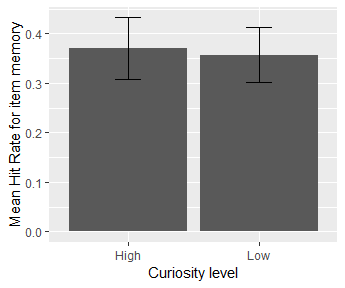

```
    Paired t-test

data:  SeenHit by RatingGroup
t = 0.49323, df = 39, p-value = 0.6246
alternative hypothesis: true difference in means is not equal to 0
95 percent confidence interval:
 -0.04414431  0.07261653
sample estimates:
mean of the differences
             0.01423611
```

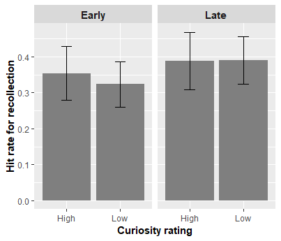

#### 4.2.3.2 Stats on it

```
Linear mixed-effects model fit by maximum likelihood
 Data: Curiosity.Recall.Old.Collapsed.Alt[!SubjectNo %in% bad.ps.less.strict]
```

|  | AIC | BIC | logLik |
| --- | --- | --- | --- |
|  | -49.78774 | -25.18635 | 32.89387 |

```
Random effects:
 Formula: ~1 | SubjectNo
        (Intercept)
StdDev:    0.138797

 Formula: ~1 | RatingGroup %in% SubjectNo
        (Intercept)
StdDev:  0.06016937

 Formula: ~1 | ItemOrderType %in% RatingGroup %in% SubjectNo
        (Intercept)   Residual
StdDev:   0.1501653 0.05195224

Fixed effects: SeenHit ~ RatingGroup * ItemOrderType
```

|  | Value | Std.Error | DF | t-value | p-value |
| --- | --- | --- | --- | --- | --- |
| (Intercept) | 0.3534722 | 0.03513112 | 78 | 10.061514 | 0.0000 |
| RatingGroupLow | -0.0298611 | 0.03847677 | 39 | -0.776082 | 0.4424 |
| ItemOrderTypeLate | 0.0354167 | 0.03598337 | 78 | 0.984251 | 0.3280 |
| RatingGroupLow:ItemOrderTypeLate | 0.0312500 | 0.05088817 | 78 | 0.614092 | 0.5409 |

```
 Correlation:
                                 (Intr) RtngGL ItmOTL
RatingGroupLow                   -0.548
ItemOrderTypeLate                -0.512  0.468
RatingGroupLow:ItemOrderTypeLate  0.362 -0.661 -0.707

Standardized Within-Group Residuals:
         Min           Q1          Med           Q3          Max
-0.786481225 -0.204375481  0.001502109  0.174403846  1.001079742

Number of Observations: 160
Number of Groups:
                                    SubjectNo                    RatingGroup %in% SubjectNo
                                           40                                            80
ItemOrderType %in% RatingGroup %in% SubjectNo
                                          160
```

# 5 Curiosity and novelty

## 5.1 Testing the effects of curiosity rating and novelty together

Build models with recollection hit rate as $y$ and examine effects of curiosity rating and novelty together by including them into the model separately and then comparing the model fits.

|  | Model | df | AIC | BIC | logLik | Test | L.Ratio | p-value |
| --- | --- | --- | --- | --- | --- | --- | --- | --- |
| baseline.rating | 1 | 4 | 13.10402 | 27.00987 | -2.552010 |  |  |  |
| rating.intercept | 2 | 5 | 15.10101 | 32.48333 | -2.550504 | 1 vs 2 | 0.0030122 | 0.9562 |
| rating.slope | 3 | 9 | 23.09645 | 54.38462 | -2.548224 | 2 vs 3 | 0.0045610 | 1.0000 |
| novelty.model | 4 | 10 | 24.37481 | 59.13944 | -2.187404 | 3 vs 4 | 0.7216394 | 0.3956 |
| interaction.model | 5 | 11 | 26.33168 | 64.57278 | -2.165839 | 4 vs 5 | 0.0431300 | 0.8355 |

## 5.2 What about the other way around

|  | Model | df | AIC | BIC | logLik | Test | L.Ratio | p-value |
| --- | --- | --- | --- | --- | --- | --- | --- | --- |
| baseline.rating | 1 | 4 | 13.10402 | 27.00987 | -2.552010 |  |  |  |
| novelty.model | 2 | 5 | 14.58150 | 31.96382 | -2.290751 | 1 vs 2 | 0.5225183 | 0.4698 |
| rating.model.1 | 3 | 6 | 16.37990 | 37.23868 | -2.189949 | 2 vs 3 | 0.2016044 | 0.6534 |
| rating.model.2 | 4 | 10 | 24.37481 | 59.13944 | -2.187404 | 3 vs 4 | 0.0050899 | 1.0000 |
| interaction.model | 5 | 11 | 26.33168 | 64.57278 | -2.165839 | 4 vs 5 | 0.0431300 | 0.8355 |

## 5.3 Check the collapsed data

# 6 Curiosity effects in the *Novel* group

## 6.1 Mean accuracy of item memory as a function of curiosity rating